# pilot analysis

2025-03-12

```r
raw_data <- list.files( path=here("../data/pilot_raw_data"), full.names=TRUE ) %>%
  map_dfr( read_csv )

data <- raw_data %>%
  filter("study_id" != "UNSAVED_STUDY",
         !is.na(study_id)) %>%
  select(-prolific_id)

write_csv(data, here("../data/pilot_data.csv"))
```

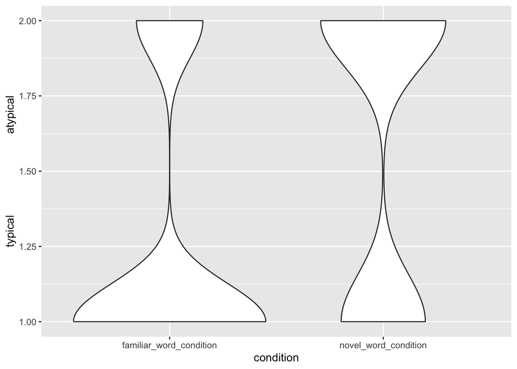

```r
data <- read_csv(here("../data/pilot_data.csv")) %>%
  mutate(stimulus_subclass = str_remove(image_name, "^[^_]*_"),
         stimulus_subclass = str_remove(stimulus_subclass, "_.*"))
data %>%
  ggplot(aes(x = condition, y = typicality)) +
  geom_violin() +
  ylab("typical                          atypical")
```

Do people tend to choose more atypical objects when prompted with a novel word?

Participants’ choices on familiar word (e.g., “leaf”) vs. novel word (e.g., “neft”) trials. Higher values indicate they chose more atypical items. Stimuli typicality scored by experimenter on a binary scale. People choose more atypical exemplars when prompted with a novel compared to a familiar word. They also strongly prefer typical exemplars when prompted with familiar words.

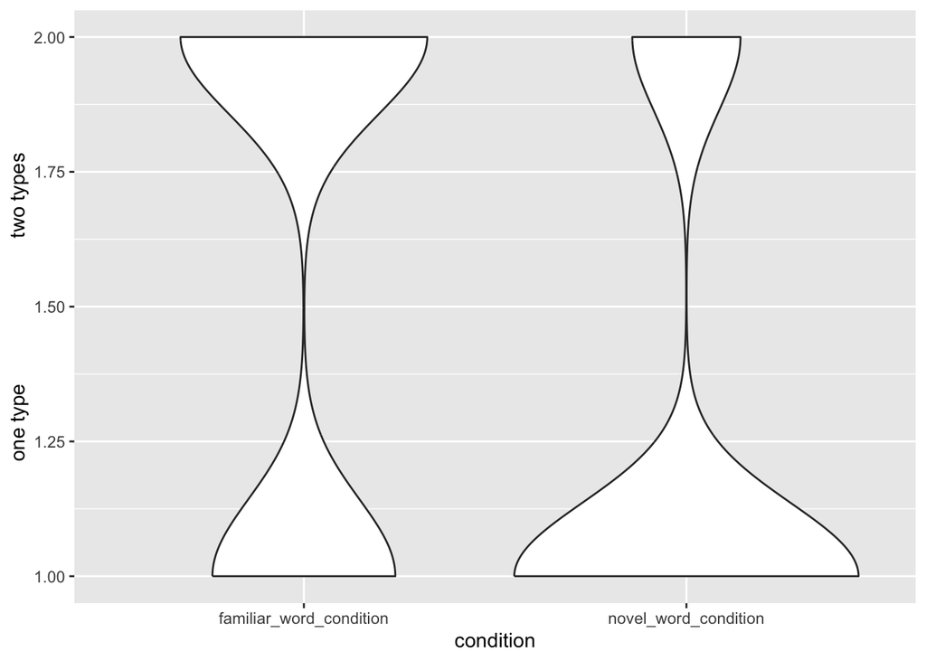

```r
data %>%
  group_by(participant_id, trial_number) %>%
  mutate(distinct_types = n_distinct(stimulus_subclass)) %>%
  ungroup() %>%
  ggplot(aes(x = condition, y = distinct_types)) +
  geom_violin() +
  ylab("one type                          two types")
```

Do people tend to choose more varied objects when prompted with familiar vs. novel words? Another way to tell whether people think the meaning of a novel word is narrower is to test whether they choose one subtype (e.g., bean-shaped leaves) vs. multiple subtypes (e.g., teardrop-shaped and oak-shaped leaves).

Above, participants’ choices of exemplars; they have two choices on each trial. A score of 1 reflects that they chose all of one subtype, and a score of 2 reflects that they chose two distinct subtypes. People tend to choose fewer distinct subtypes when prompted with novel words.